# PoER: Ch. 1 - Team Nudi

Jessica, Bertamus, Sean, Vincent

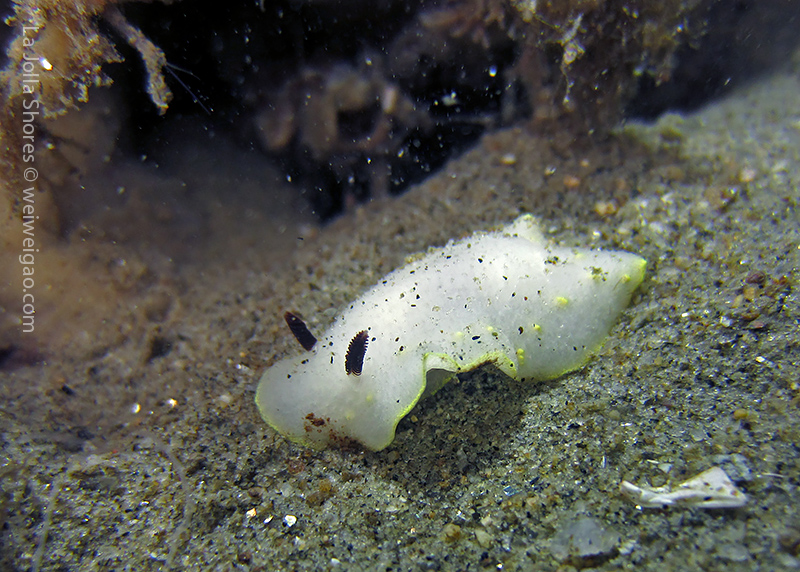

```r
knitr::opts_chunk$set(fig.width = 6, fig.height = 4,
                      echo = TRUE, message = FALSE, warning = FALSE) # JLC removed the argument 'fig.path' and now the figs aren't written each time :D

library(tidyverse)
library(RColorBrewer) # Just additional color palettes you can use. Not necessary to load this.

### The book has an R package!
library(primer) # install.packages('primer')
library(cowplot)
```

# Chapter 1

## 1.3 Exploring Population Growth

#### Simple Graphing of Population Size (Fig. 1.3)

Here we create two vectors: population size, $N$, and years. Using `c()` allows us to create an arbitrary vector, and the colon, `:`, provides a sequence of consecutive integers.

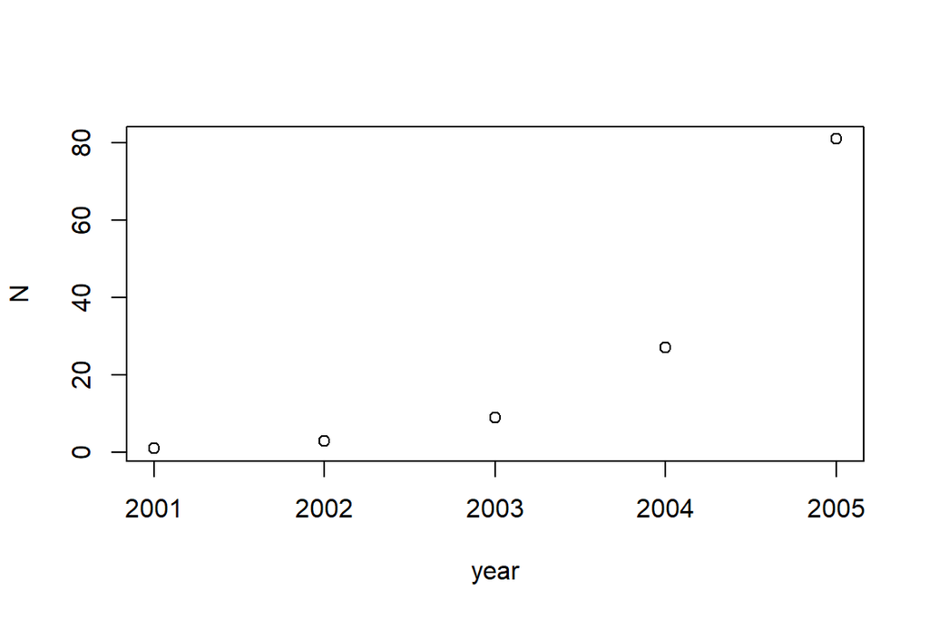

```r
### Original version
N <- c(1, 3, 9, 27, 81)
year <- 2001:2005
plot(year, N)
```

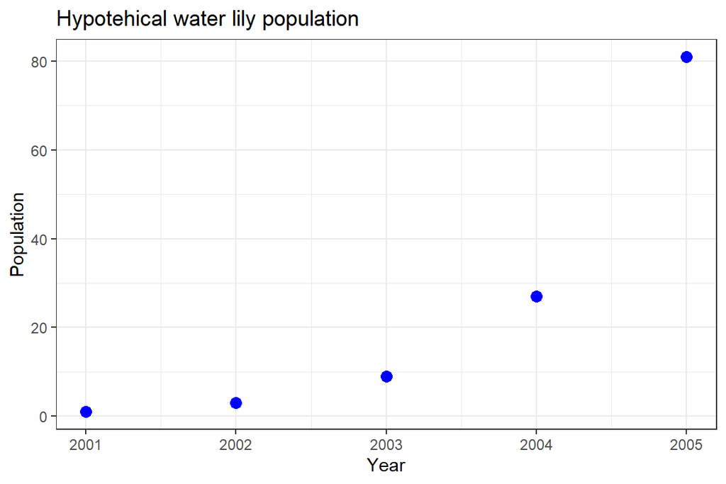

```r
### JLC's version
expGrw <- data.frame(N = c(1, 3, 9, 27, 81),
                         year = 2001:2005)
ggplot(expGrw, aes(x = year, y = N)) +
  geom_point(color = 'blue', size = 3) +
  labs(x = 'Year', y = 'Population',title = "Hypotehical water lily population")+
  theme_bw()
```

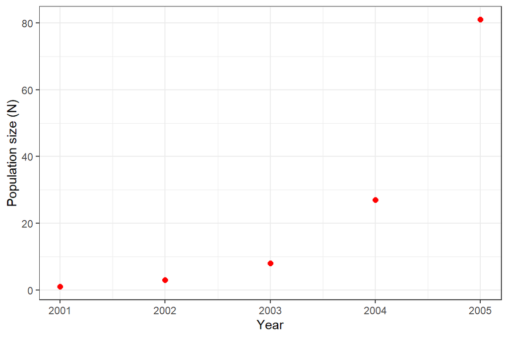

```r
# Sean's version

exp_growth <- data.frame(N = c(1, 3, 8, 27, 81), year = 2001:2005)

exp_growth_plot <- ggplot(exp_growth, aes(x= year, y = N)) +
   geom_point(color = 'red', size = 2) +
  theme_bw() +
  labs(x = 'Year', y = 'Population size (N)')
exp_growth_plot
```

The lily population (Fig. 1.3) increases by a different amount each year. What about proportions — does it increase by a different proportion each year? Let’s divide each year’s population size by the previous year’s size, that is, perform $N_{t+1}/N_t$ for all $t$, where $t$ is any particular point in time, and $t + 1$ is the next point in time. For $N$, that amounts to 3/1, 9/3, . . . . What do we notice?

#### Vectorized math

Here we divide each element of one vector (the second through fifth element of $N$) by each element of another vector (the first through fourth elements of $N$).

```r
rates = N[2:5]/N[1:4]
rates
```

```
## [1] 3 3 3 3
```

```r
# [1] 3 3 3 3
```

```r
### JLC's version

expGrw<-expGrw %>%
  mutate(rate=N/lag(N))

expGrw$rate[2:nrow(expGrw)]
```

```
## [1] 3 3 3 3
```

### 1.3.1 Projecting population size

Here we calculate population sizes for 10 time points beyond the initial. First we assign values for $N_0$, $\lambda$, and time.

# Question: Can someone describe the use of notation $ and `\` in the text above? -Sean

```r
N0 <- 1
lambda <- 2
time <- 0:10
```

Next we calculate $N_t$ directly using our general formula.

```r
Nt <- N0 * lambda^time
Nt
```

```
##  [1]    1    2    4    8   16   32   64  128  256  512 1024
```

```r
# [1] 1 2 4 8 16 32 64 128 256 5121024
```

Note: $\lambda$ = finite rate of increase (the per capita rate of growth of a population if the population is growing geometrically)

### 1.3.2 Effects of Initial Population Size

We first set up several different initial values, provide a fixed $\lambda$, and set times from zero to 4.

```r
N0 <- c(10, 20, 30)
lambda <- 2
time <- 0:4
```

We calculate population sizes at once using `sapply` to *apply* a function (`n*lambda^time`) to each element of the first argument (each element of `N0`).

```r
Nt.s <- sapply(N0, function(n) n*lambda^time) # n here is just a variable - it could be anything

Nt.s
```

```
##      [,1] [,2] [,3]
## [1,]   10   20   30
## [2,]   20   40   60
## [3,]   40   80  120
## [4,]   80  160  240
## [5,]  160  320  480
```

```r
#      [,1] [,2] [,3]
# [1,]   10   20   30
# [2,]   20   40   60
# [3,]   40   80  120
# [4,]   80  160  240
# [5,]  160  320  480
```

The result is a matrix, and we see $N_0$ in the first row, and each population is in its own column. Note that population 2 is always twice as big as population 1.

#### Graphing a Matrix (Figs. 1.3a, 1.3b)

We can use matplot to plot a matrix vs. a single vector on the X-axis. By default it labels the points according to the number of the column

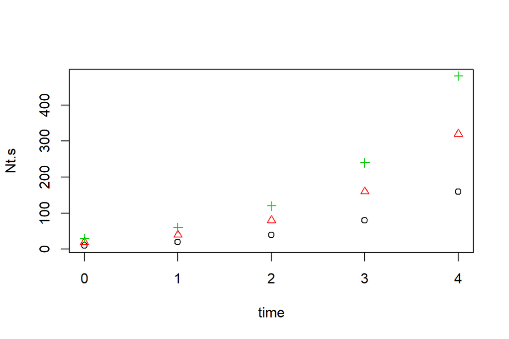

```r
matplot(time, Nt.s, pch = 1:3)
```

We can also plot it with a log scale on the y-axis.

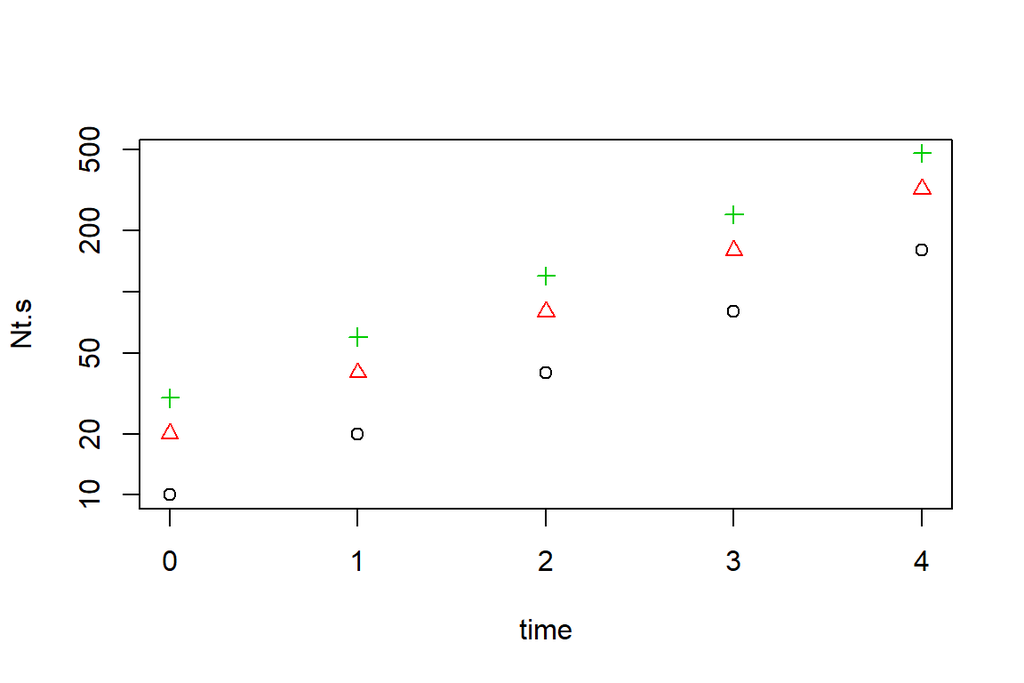

```r
matplot(time, Nt.s, log = "y", pch = 1:3)
```

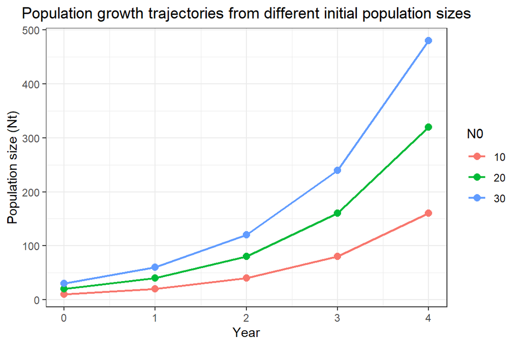

```r
# Sean's version

# Use crossing() to make a data frame for all combinations of N0 and time
# Use mutate() to create a new column)

exp_pop_df <- crossing(time, N0) %>%
  mutate(Nt = N0*lambda^time) %>%
  mutate(N0 = factor(N0))

exp_pop_plot <- ggplot(exp_pop_df, aes(x = time, y = Nt, color = N0)) +
  geom_point(size = 2.5) +
  labs(x = 'Year', y = 'Population size (Nt)') +
  geom_line(aes(group = N0), size = 0.8) +
  theme_bw() +
  ggtitle("Population growth trajectories from different initial population sizes") +
  theme(plot.title = element_text(hjust = 0.5)) #to center the title
exp_pop_plot
```

```r
# Question: How do I change the scale on the right so it's not continuous but just reflects the three N0 values?

# Answer (which you've now done above): mutate the N0 data into factors. Before they were read as continuous, but now it knows to separate them.
```

```r
# JLC's version

lamb<-2

nts<-crossing(N0=c(10,20,30),
              time=c(0:4)) %>%
  mutate(nts=N0*lamb^time) %>%
  mutate(ntsLog=log(nts))

head(nts) # we don't get the easy-view N0 x time format in the tidy df, but its 'tidy' and easier to manipulate
```

```
## # A tibble: 6 x 4
##      N0  time   nts ntsLog
##   <dbl> <int> <dbl>  <dbl>
## 1    10     0    10   2.30
## 2    10     1    20   3.00
## 3    10     2    40   3.69
## 4    10     3    80   4.38
## 5    10     4   160   5.08
## 6    20     0    20   3.00
```

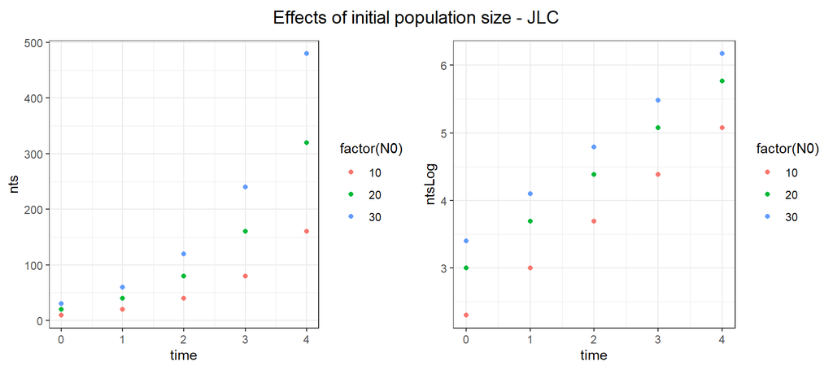

```r
ntsPl<-ggplot(nts,aes(time,nts))+
  geom_point(aes(colour=factor(N0)))+
  theme_bw()

ntsPlLg<-ggplot(nts,aes(time,ntsLog))+
  geom_point(aes(colour=factor(N0)))+
  theme_bw()

nts2<-plot_grid(ntsPl,ntsPlLg)

ntsTitle<-ggdraw() + draw_label("Effects of initial population size - JLC")

plot_grid(ntsTitle, nts2, ncol=1, rel_heights=c(0.1, 1))
```

### 1.3.3 Effects of different per capita growth rates

Here we demonstrate the effects on growth of $\lambda > 1$ and $\lambda < 1$. We set $N_0 = 100$, and time, and then pick three different $\lambda$.

```r
N0 <- 100
time <- 0:3
lambdas <- c(0.5, 1, 1.5)
```

We use `sapply` again to apply the geometric growth function to each $\lambda$. This time, `x` stands for each $\lambda$, which our function then uses to calculate population size. We then plot it, and add a reference line and a little text.

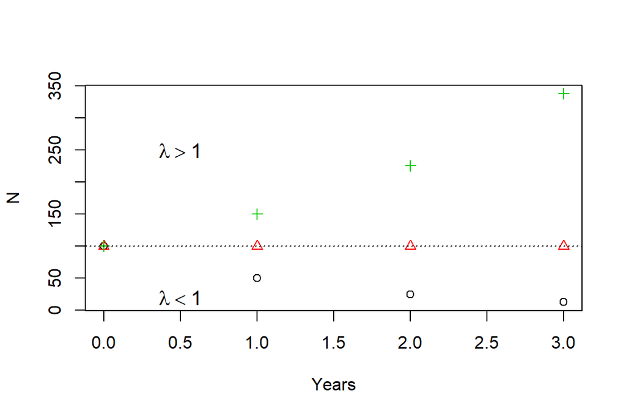

```r
N.all <- sapply(lambdas, function(x) N0 * x^time)
matplot(time, N.all, xlab = "Years", ylab = "N", pch = 1:3)
abline(h = N0, lty = 3)
text(0.5, 250, expression(lambda > 1), cex = 1.2)
text(0.5, 20, expression(lambda < 1), cex = 1.2)
```

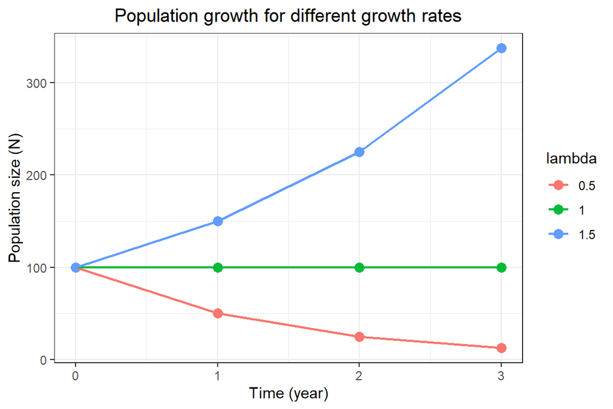

```r
# Sean's version

N0 <- 100
time <- 0:3
lambda <- c(0.5, 1.0, 1.5)

# Use crossing() to make a data frame for all combinations of N0 and lambda
# Use mutate() to create a new column)

df_lambda <- crossing(lambda, time) %>%
  mutate(Nt = N0*lambda^time) %>%
  mutate(N0 = N0) %>%
    mutate(lambda = factor(lambda))

#QUESTION How would I add N0 back in without  using mutate to create a new column? Also, how would I move my mutated column (above) to the left?

lambda_plot <- ggplot(df_lambda, aes(x = time, y = Nt, color = lambda)) +
  geom_point(size = 3) +
  geom_line(aes(group = lambda), size = 0.8) +
  theme_bw() +
  labs(x = "Time (year)", y = "Population size (N)") +
  ggtitle("Population growth for different growth rates") +
  theme(plot.title = element_text(hjust = 0.5))
lambda_plot
```

```r
# JLC's version

N_0<-100

nLam<-crossing(lamb=c(0.5,1.0,1.5),
              time=c(0:3)) %>%
  mutate(nLam=N_0*lamb^time)

head(nLam) # we don't get the easy-view N0 x time format in the tidy df, but its 'tidy' and easier to manipulate
```

```
## # A tibble: 6 x 3
##    lamb  time  nLam
##   <dbl> <int> <dbl>
## 1   0.5     0 100
## 2   0.5     1  50
## 3   0.5     2  25
## 4   0.5     3  12.5
## 5   1       0 100
## 6   1       1 100
```

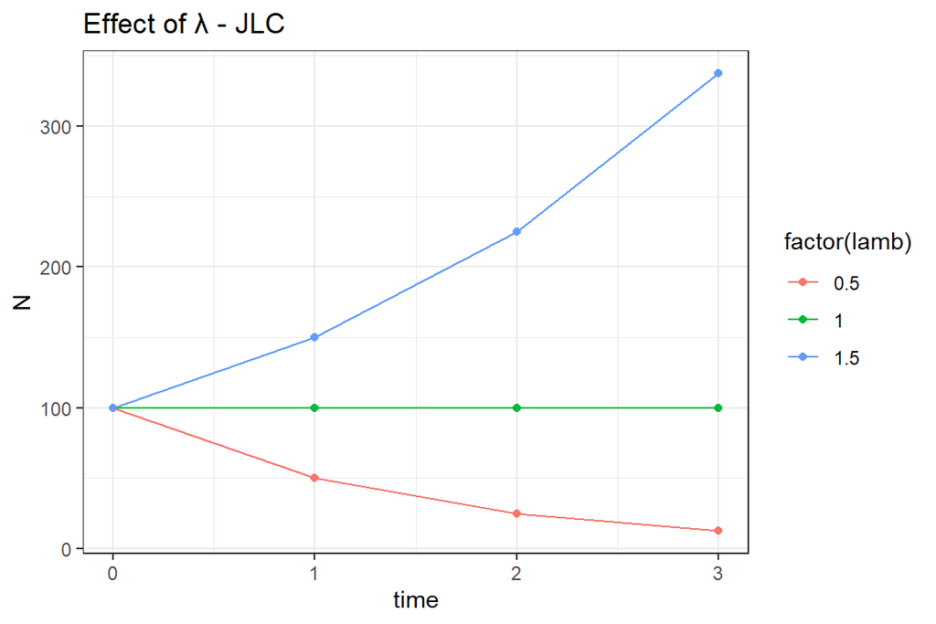

```r
nLamPl<-ggplot(nLam,aes(time,nLam))+
  geom_point(aes(colour=factor(lamb)))+
  geom_line(aes(colour=factor(lamb)))+
  labs(title="Effect of \u03bb - JLC", y="N")+
  theme_bw()

nLamPl
```

The reference line is a *h*orizontal line with the *l*ine *ty*pe dotted. Our text simply indicates the regions of positive and negative growth.

### 1.3.4 Average growth rate

#### Comparing arithmetic and geometric averages (Fig. 1.5)

First we select the number of observed $R$ $(t = 5)$; this will require that we use six years of Song Sparrow data.

```r
t <- 5
data(sparrows)
SS6 <- sparrows[1:(t + 1), ]
```

Next we calculate $\lambda$ for each generation, from $t$ to $t + 1$, and calculate the arithmetic and geometric means.

```r
SSgr <- SS6$Count[2:(t + 1)]/SS6$Count[1:t]
lam.A <- sum(SSgr)/t
lam.G <- prod(SSgr)^(1/t)
```

Now we can plot the data, and the projections based on the two averages (Fig. 1.5).

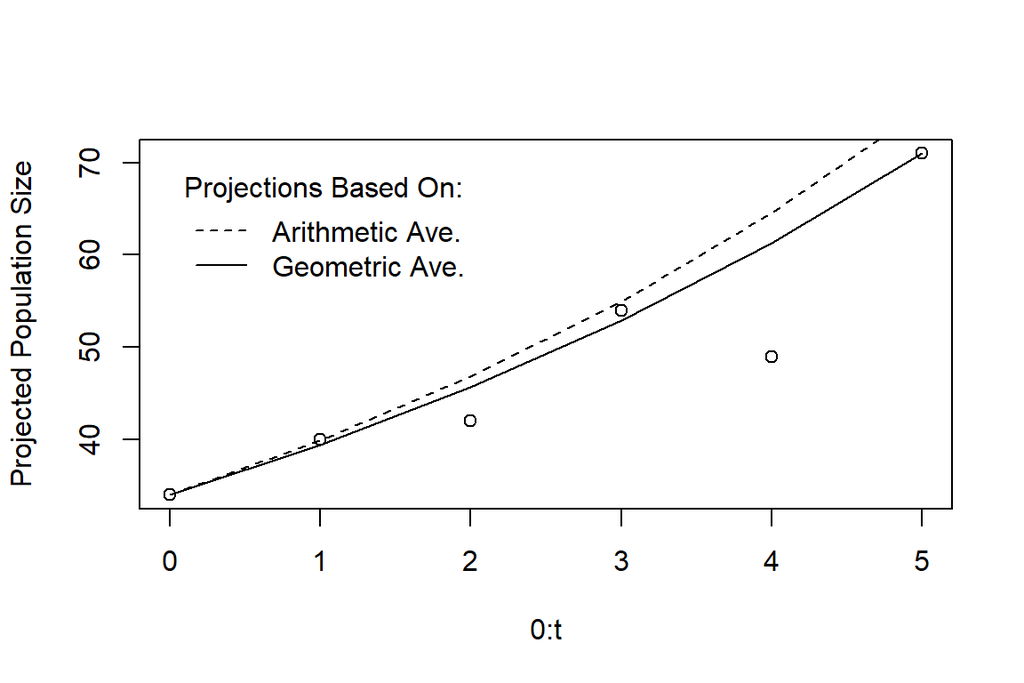

```r
N0 <- SS6$Count[1]
plot(0:t, SS6$Count, ylab = "Projected Population Size")
lines(0:t, N0 * lam.A^(0:t), lty = 2)
lines(0:t, N0 * lam.G^(0:t), lty = 1)
legend(0, 70,
       c("Arithmetic Ave.", "Geometric Ave."),
       title = "Projections Based On:",
       lty = 2:1, bty = "n", xjust = 0)
```

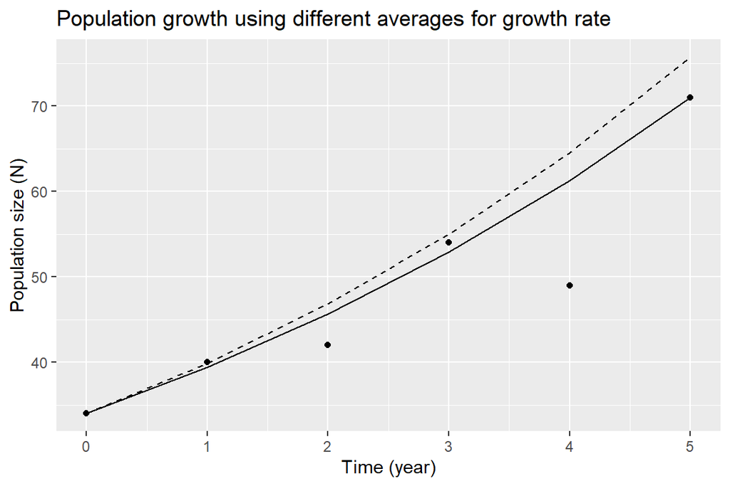

```r
# Sean's version

# First, load data from the 'primer' package
data(sparrows)
t <- 5
N0 <- sparrows$Count[1]

df_averages <- sparrows %>%
  slice(1:(t+1)) %>% # you've made t a value above. It's five.
  mutate(lambda = Count/lag(Count)) %>%
  mutate(lambda_a = sum(na.omit(lambda))/t) %>%
  mutate(lambda_g = prod(na.omit(lambda))^(1/t)) %>%
  mutate(N_lambda_a = N0*lambda_a^(Year-1966)) %>%
  mutate(N_lambda_g = N0*lambda_g^(Year-1966))

#slice is like filter but instead of choosing rows based on values you choose rows based on the row number.

# Now, make the plot:

lambda_plot <- ggplot(df_averages, aes(x = (Year-1966), y = Count)) +
  geom_point(size = 1.5) +
  geom_line(aes(x = (Year-1966), y = N_lambda_a), lty = 2) +
  geom_line(aes(x = (Year-1966), y = N_lambda_g), lty = 1) +
  labs(x = "Time (year)", y = "Population size (N)") +
  ggtitle("Population growth using different averages for growth rate")
lambda_plot
```

```r
# QUESTION: How did Jess just plot time below? Do we also not need to specify "x =" and "y="?

#Answer: NOPE
```

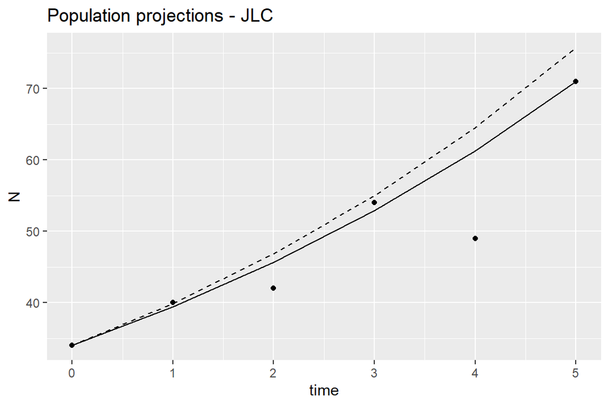

```r
# JLC's version

data(sparrows)

t<-5
N0<-sparrows[1,"Count"]

ss6<-sparrows %>%
  slice(1:(t+1)) %>%
  mutate(ssGr=Count/lag(Count)) %>%
  mutate(lamA=sum(na.omit(ssGr))/t)%>%
  mutate(lamG=prod(na.omit(ssGr))^(1/t)) %>%
  mutate(time=Year-1966) %>%
  mutate(nA=N0*lamA^(time)) %>%
  mutate(nG=N0*lamG^(time))

ggplot(ss6,aes(time,Count))+
  geom_point()+
  geom_line(aes(time,nA),lty=2)+
  geom_line(aes(time,nG),lty=1)+
  labs(title = "Population projections - JLC",y="N")
```

```r
# Could also change size and color of lines by adding these in, outside of aes(). Remember, the names/codes for colors go in quotes.
```

## 1.4 Continuous Exponential Growth

### 1.4.1 Motivating continuous exponential growth

#### Numerical approximation of *e*

Here we use brute force to try to get an approximate solution to eq. 1.9. We’ll let n be the number of divisions within one year. This implies that the finite rate of increase during each of these fractional time steps is $r_d/n$. Let the $\lambda = 2$ and therefore $r_d = 1$. Note that because $N_0 = 1$, we could ignore it, but let’s keep it in for completeness.

```r
n <- 0:100
N0 <- 1
rd <- 1
```

Next, we calculate $\left( 1 + \frac{r_d}{n} \right)^n$ for ever larger values of $n$.

```r
N1 <- N0 * (1 + rd/n)^n
```

Last, we plot the ratio and add some fancy math text to the plot (see `?plotmath` for details on mathematical typesetting in R).

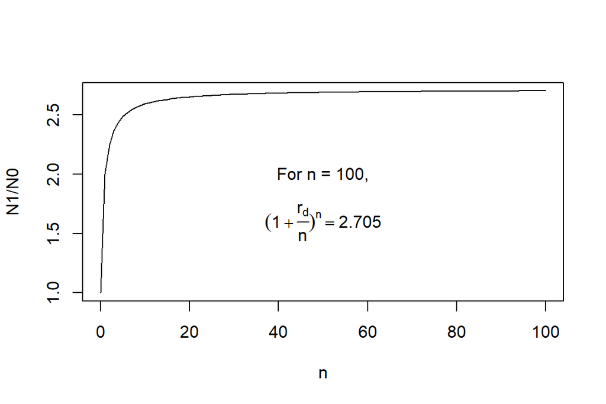

```r
plot(n, N1/N0, type = "l")
text(50, 2, "For n = 100,")
text(50, 1.6,
     bquote((1+frac("r"["d"],"n"))^"n" == .(round(N1[101]/N0, + 3))))
```

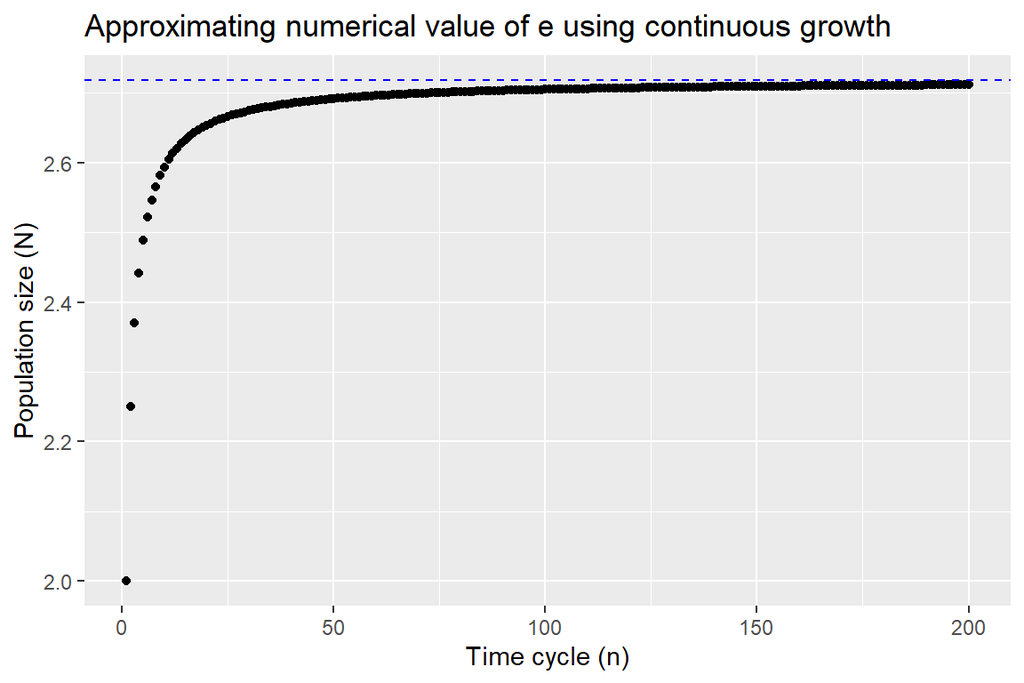

```r
# Sean's version

#How do you use data.frame? What goes into making a dataset?

#r_d is the intrinsic rate of increase or instantaneous per capita rate of increase

e_df_sd <- data.frame(n = 1:200, N0 = 1, r_d = 1) %>%
  mutate (N1 = N0*(1 + r_d/n)^n)

e_plot <- ggplot(e_df_sd, aes(x = n, y = N1)) +
  geom_point() +
  geom_hline(yintercept = exp(1), color = 'blue', lty = 2) +
  labs(x = "Time cycle (n)", y = "Population size (N)") +
  ggtitle("Approximating numerical value of e using continuous growth")
e_plot
```

Fig. 1.6: The limit to subdividing reproduction into smaller steps. We can compare this numerical approximation to the true value, $e^1 = 2.718$.

#### Projecting a continuous population

We select five different values for $r$: two negative, zero, and two positive. We let $t$ include the integers from 1 to 100. We then use `sapply` to apply our function of continuous exponential growth to each $r$, across all time steps. This results in a matrix where each row is the population size at each time $t$, and each column uses a different $r$.

```r
r <- c(-0.03, -0.02, 0, 0.02, 0.03)
N0 <- 2
t <- 1:100
cont.mat <- sapply(r, function(ri) N0 * exp(ri * t))
```

Next we create side-by-side plots, using both arithmetic and logarithmic scales, and add a legend.

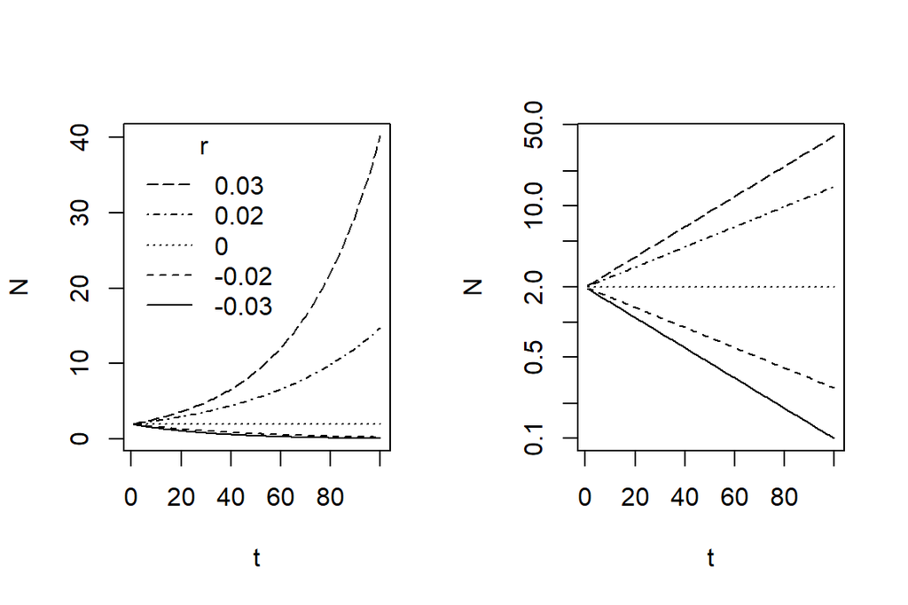

```r
layout(matrix(1:2, nrow = 1))
matplot(t, cont.mat, type = "l", ylab = "N", col = 1)
legend("topleft", paste(rev(r)),
       lty = 5:1, col = 1, bty = "n",
       title = "r")
matplot(t, cont.mat, type = "l", ylab = "N", log = "y", col = 1)
```

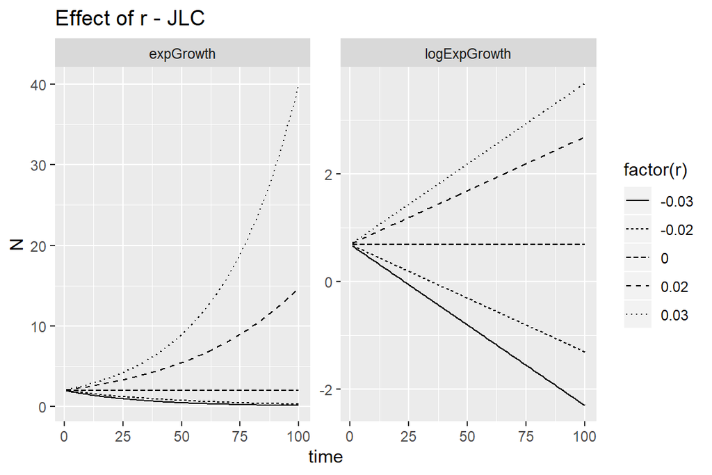

```r
### JLCs version

n0<-2

proj<-crossing(r=c(-0.03,-0.02,0,0.02,0.03),
               time=1:100)%>%
  mutate(expGrowth=n0*exp(r*time)) %>%
  mutate(logExpGrowth=log(expGrowth)) %>%
  gather(key=rateDef,value=pop,-c(time,r))

projPlt<-ggplot(proj,aes(time,pop))+
  geom_line(aes(lty=factor(r)))+ # What does a line type of factor(r) mean?
  facet_wrap(~rateDef,scales = "free")+
  labs(title="Effect of r - JLC",y="N") # So we don't need to separately add the title?

projPlt
```

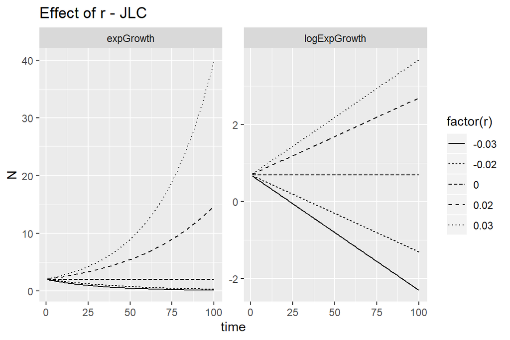

```r
# Sean's version

N0 <-2
proj_cont <- crossing(r = c(-0.03, -0.02, 0, 0.02, 0.03), time = 1:100) %>%
  mutate(exp_growth = N0*(r*time)) %>%
  mutate(log_exp_growth <- log(exp_growth)) %>%
  gather(key=rateDef,value=pop,-c(time,r))

# What did Jess do in the last line (above)?



projPlt<-ggplot(proj,aes(time,pop))+
  geom_line(aes(lty=factor(r)))+ # What does a line type of factor(r) mean?
  facet_wrap(~rateDef,scales = "free")+
  labs(title="Effect of r - JLC",y="N") # So we don't need to separately add the title?

projPlt
```

### 1.4.3 Doubling (and tripling) time

#### Creating a function for doubling time

We can create a function for this formula, and then evaluate it for different values of $m$ and $r$. For $m = 2$, we refer to this as “doubling time.” When we define the function and include arguments $r$ and $m$, we also set a default value for `m = 2`. This way, we do not always have to type a value for $m$; by default the function will return the doubling time.

```r
m.time <- function(r, m = 2) {
  log(m)/r
}
```

Now we create a vector of $r$, and then use `m.time` to generate a vector of doubling times.

```r
rs <- c(0, 1, 2)
m.time(rs)
```

```
## [1]       Inf 0.6931472 0.3465736
```

```r
# [1]    Inf 0.6931 0.3466
```

Note that R tells us that when $r = 0$, it takes an infinite (`Inf`) amount of time to double. This is what we get when we try to divide by zero!

```r
# JLCs version
m=2

doub<-data.frame(r=c(0,1,2))%>%
  mutate(doubTime=log(m)/r)

doub
```

```
##   r  doubTime
## 1 0       Inf
## 2 1 0.6931472
## 3 2 0.3465736
```

## 1.6 Modeling with Data: Simulated Dynamics

### 1.6.2 Looking at and collecting the data

```r
names(sparrows)
```

```
## [1] "Year"           "Count"          "ObserverNumber"
```

```r
# [1] "Year"           "Count"          "ObserverNumber"
attach(sparrows)
```

Now we plot these counts through time (Fig. 1.8).

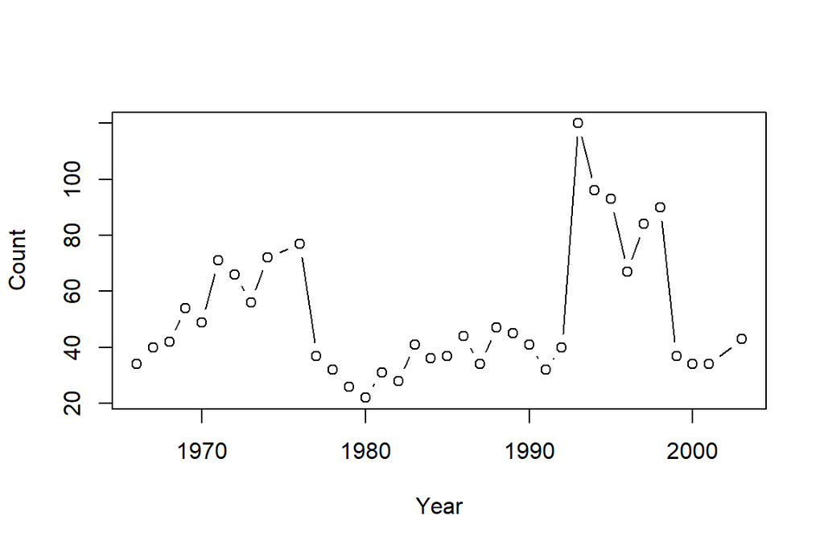

```r
plot(Count ~ Year, type = "b")
```

```r
obs.R <- Count[-1]/Count[-length(Count)]
```

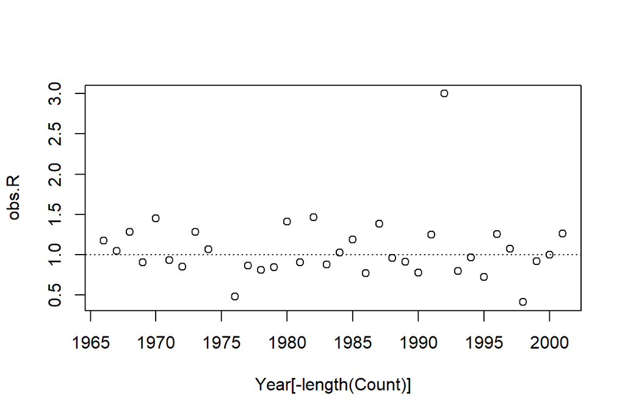

```r
plot(obs.R ~ Year[-length(Count)])
abline(h = 1, lty = 3)
```

### 1.6.3 One simulation

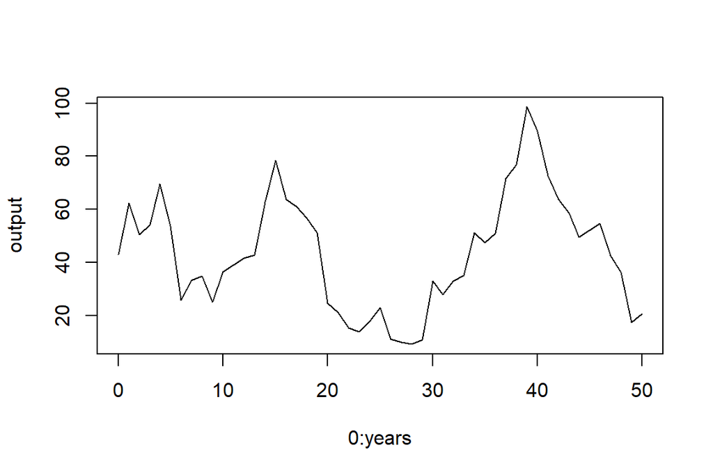

```r
years <- 50
set.seed(3)
sim.Rs <- sample(x = obs.R, size = years, replace = TRUE)

output <- numeric(years + 1)

output[1] <- Count[Year == max(Year)]

for (t in 1:years) output[t + 1] <- {
  output[t] * sim.Rs[t]
}

plot(0:years, output, type = "l")
```

### 1.6.4 Multiple simulations

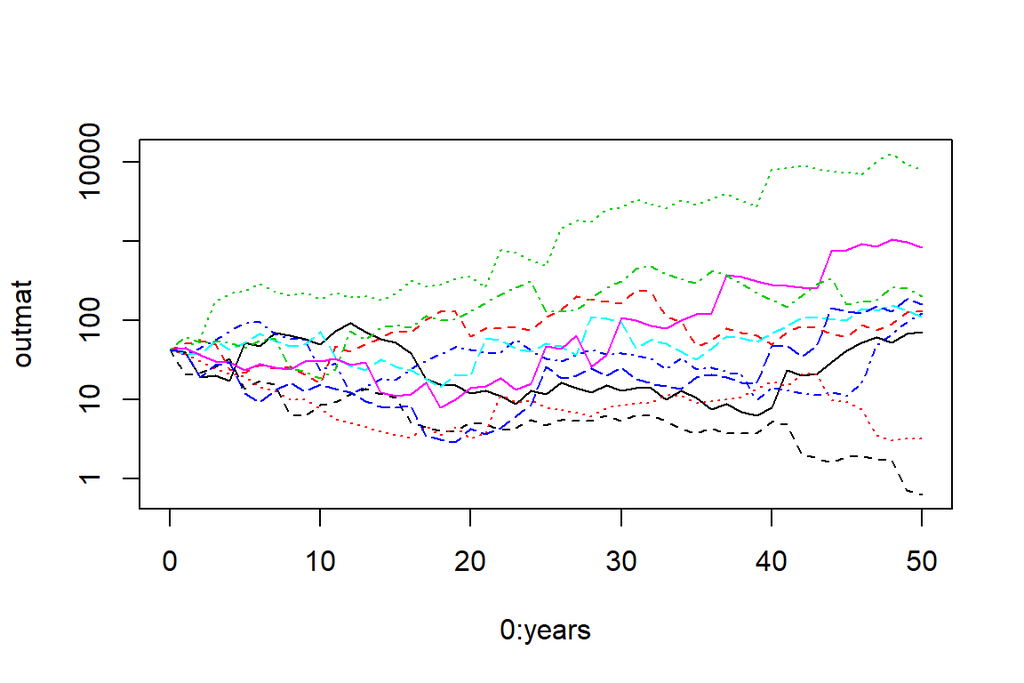

```r
sims = 10
sim.RM <- matrix(sample(obs.R, sims * years, replace = TRUE),
                 nrow = years, ncol = sims)

output[1] <- Count[Year == max(Year)]
outmat <- sapply(1:sims, function(i) {
  for (t in 1:years) output[t + 1] <- output[t] * sim.RM[t, i]
  output
  })

matplot(0:years, outmat, type = "l", log = "y")
```

### 1.6.5 Many simulations, with a function

```r
PopSim <- function(Rs, N0, years = 50, sims = 10) {
  sim.RM = matrix(sample(Rs, size = sims * years, replace = TRUE),
                  nrow = years, ncol = sims)
  output <- numeric(years + 1)
  output[1] <- N0
  outmat <- sapply(1:sims, function(i) {
    for (t in 1:years) output[t + 1] <- round(output[t] * sim.RM[t, i], 0)
    output
  })
  return(outmat)
}
```

```r
system.time(output <- PopSim(Rs = obs.R, N0 = 43, sims = 1000))
```

```
##    user  system elapsed
##    0.04    0.00    0.05
```

```r
#  user  system elapsed
# 0.404   0.004   0.407
```

This tells me that it took less than half a second to complete 1000 simulations. That helps me understand how long 100,000 simulations might take. We also check the dimensions of the output, and they make sense.

```r
dim(output)
```

```
## [1]   51 1000
```

```r
# [1] 51 1000
```

### 1.6.6 Analyzing results

```r
N.2053 <- output[51, ]
summary(N.2053, digits = 6)
```

```
##    Min. 1st Qu.  Median    Mean 3rd Qu.    Max.
##     0.0    12.0    60.5   743.9   311.5 72989.0
```

```r
# Min.  1st Qu.   Median     Mean  3rd Qu.     Max.
#  0.0     14.0     66.0   1124.6    291.8 332236.0
```

```r
quantile(N.2053, prob = c(0.0275, 0.975))
```

```
##   2.75%   97.5%
##    0.00 4966.85
```

```r
# 2.75% 97.5%
#     0  5967
```

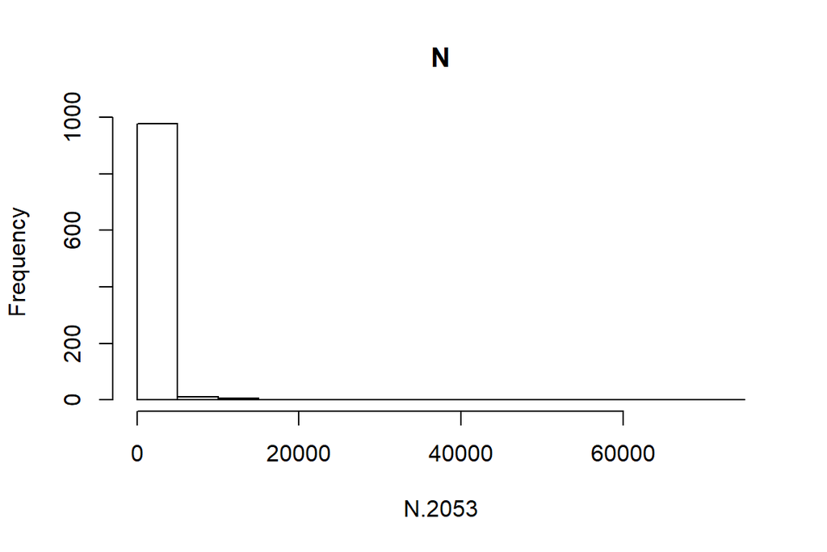

```r
hist(N.2053, main = "N")
```

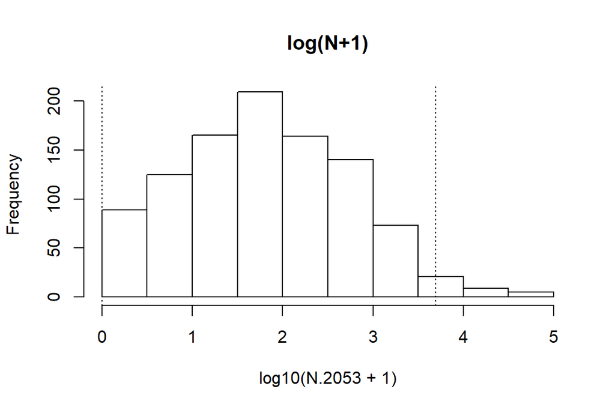

```r
hist(log10(N.2053 + 1), main = "log(N+1)")
abline(v = log10(quantile(N.2053, prob = c(0.0275, 0.975)) + 1),
       lty = 3)
```

```r
logOR <- log(obs.R)
n <- length(logOR)
t.quantiles <- qt(c(0.025, 0.975), df = n - 1)

se <- sqrt(var(logOR)/n)
CLs95 <- mean(logOR) + t.quantiles * se

R.limits <- exp(CLs95)
R.limits
```

```
## [1] 0.8967762 1.1301703
```

```r
# [1] 0.8968 1.1302

N.Final.95 <- Count[Year == max(Year)] * R.limits^50
round(N.Final.95)
```

```
## [1]     0 19528
```

```r
# [1] 0 19528
```

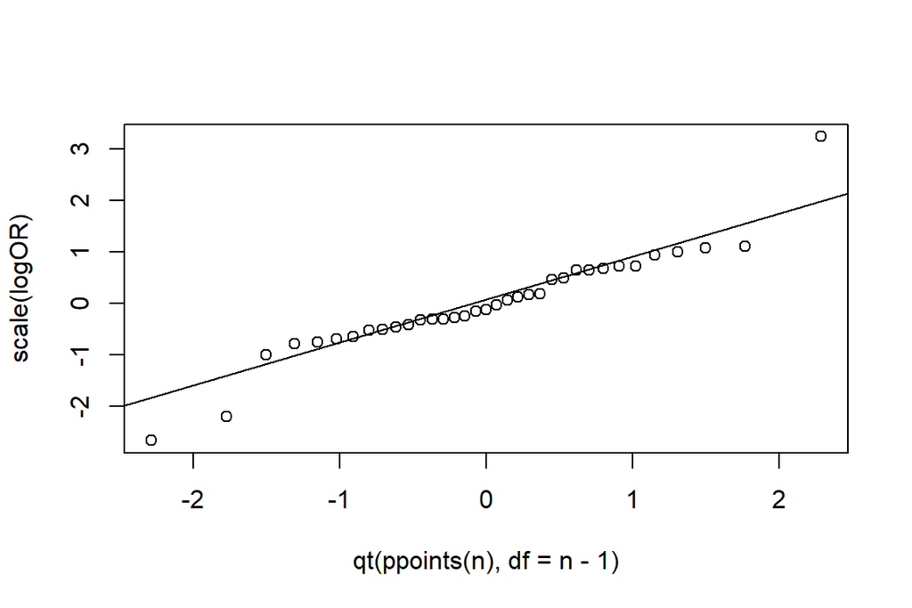

```r
qqplot(qt(ppoints(n), df = n - 1), scale(logOR))
qqline(scale(logOR))
```

## End of chapter questions

### 1.1. Geometric growth Analyze the following data, relying on selected snippets of previous code.

1. In the years 1996 through 2005, lily population sizes are $N = 150, 100, 125, 200, 225, 150, 100, 175, 100, 150$. Make a graph of population size versus time.

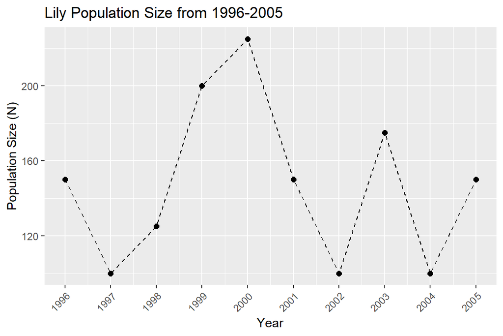

```r
lily_df <- data.frame(N = c(150, 100, 125, 200, 225, 150, 100, 175, 100, 150), year = 1996:2005)

lily_plot <- ggplot(lily_df, aes(x = year, y = N)) +
  geom_point(size = 2) +
  geom_line(lty = 2) +
  ggtitle('Lily Population Size from 1996-2005') +
  scale_x_continuous(breaks = 1996:2005) +
  labs(x = "Year", y = "Population Size (N)") +
  theme(axis.text.x = element_text(angle = 45, hjust = 1))
lily_plot
```

2. Calculate $R$ for each year; graph $R$ vs. time.

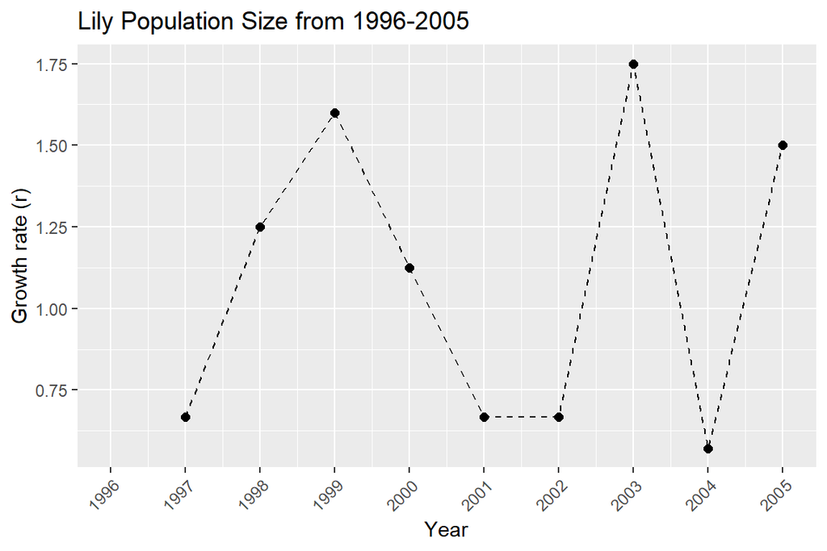

```r
lily_df <- lily_df %>%
  mutate(r = N/lag(N))

lily_rate <- ggplot(lily_df, aes(x = year, y = r)) +
                      geom_point(size = 2) +
  geom_line(lty = 2) +
  ggtitle('Lily Population Size from 1996-2005') +
  scale_x_continuous(breaks = 1996:2005) +
  labs(x = "Year", y = "Growth rate (r)") +
  theme(axis.text.x = element_text(angle = 45, hjust = 1))
lily_rate
```

3. Calculate arithmetic and geometric average growth rates of this population.
4. Based on the appropriate average growth rate, what would be the expected population size in 2025? What would the estimated population size be if you used the inappropriate mean? Do not use simulation for this.
5. Given these data, develop simulations as above with the user-defined function, `PopSim`. Describe the distribution of projected population sizes for 2010.

### 1.2. Doubling Time

1. Derive the formula for doubling time in a population with continuous exponential growth.

```r
doubTime<-function(r,m=2){
  log(m)/r
}
doubTime(c(0,1,2))
```

```
## [1]       Inf 0.6931472 0.3465736
```

2. What is the formula for tripling time?

```r
doubTime(c(0,1,2),3)
```

```
## [1]       Inf 1.0986123 0.5493061
```

3. If we are modeling humans or *E. coli*, would a model of geometric, or exponential growth be better? Why?

*Geometric growth = discrete growth*  
*Exponential growth = continuous growth*

The answer depends a bit on the scale, but humans are usually best modeled with geometric growth since humans cannot have more than one reproduction event in a year, for example. *E. coli* more appropriately modeled with exponential growth since they grow rapidly and asexually, so with few limitations.

4. If an *E. coli* population grew from 1000 cells to 2 × 10<sup>9</sup> cells in 6 h, what would its intrinsic rate of increase be? Its doubling time?
   $$N_t = N_0e^{rt}$$
   $$2*10^{9}=(1*10^{3})e^{6r}$$
   $$2*10^{6}=e^{6r}$$
   $$ln(2*10^{6})=6r$$
   $$r=\frac{ln(2*10^{6})}{6}$$
   r = 2.4181096

### 1.3. Human Population Growth

1. There were about 630 million people on the planet in 1700, and 6.3 billion in 2003 [33]. What was the intrinsic rate of increase, r?

```r
# Vincent's answer

calc_intric_rate <- function(final_pop = 6.3, initial_pop = 0.630, final_period = 2003, initial_period = 1700){

  rate <- (log(final_pop)-log(initial_pop))/(final_period-initial_period)

  return(rate)
}
```

So the intrinsic rate of growth is 0.01 new individual per human per year.

Alternatively, we could use a regression based method to figure this out. Indeed, since we know that $N_{t+1} - N_t \approx\frac{dN_t}{dt} = N_tr$, we can run the following linear model:

$(N_{t+1} - N_t) = \beta N_t + \epsilon_t$

where $\beta = r$ and $\epsilon_t$ an error term. Below I estimate the above equation using World Bank global population data

```r
library("wbstats")
library("dplyr")

pop_wb <- wb(indicator = "SP.POP.TOTL")

pop_wb_w <- pop_wb %>%
  filter(country == "World") %>%
  mutate(change = value - dplyr::lead(value), lead_value = dplyr::lead(value))

lm_pop <- lm(change ~  0 + lead_value, data=pop_wb_w)
```

Using the 1960 to 2018 world population data, we find a similar intrinsic growth rate as $\hat{\beta}=$ 0.014.

2. Graph the model of human population size population size from 1700 to 2020.

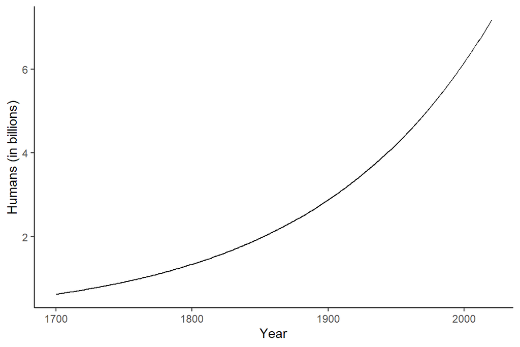

```r
# Vincent's answer

## Function to create population data frame
create_pop_data <- function(initial_pop = 0.630, first_year = 1700, last_year = 2020){

  pop <- data.frame(year = first_year:last_year,
                  population = c(initial_pop,initial_pop*exp(calc_intric_rate()*1:(last_year -  first_year))))

  return(pop)

}

## Graphing

graph1b <- ggplot(create_pop_data(), aes(x=year, y=population)) +
                  geom_line() +
                  labs(x = "Year", y = "Humans (in billions)") +
                  theme(axis.text = element_text(size=rel(0.55))) +
                  theme_classic()
```

3. Add points on the graph indicating the population doublings from 1700 onward.

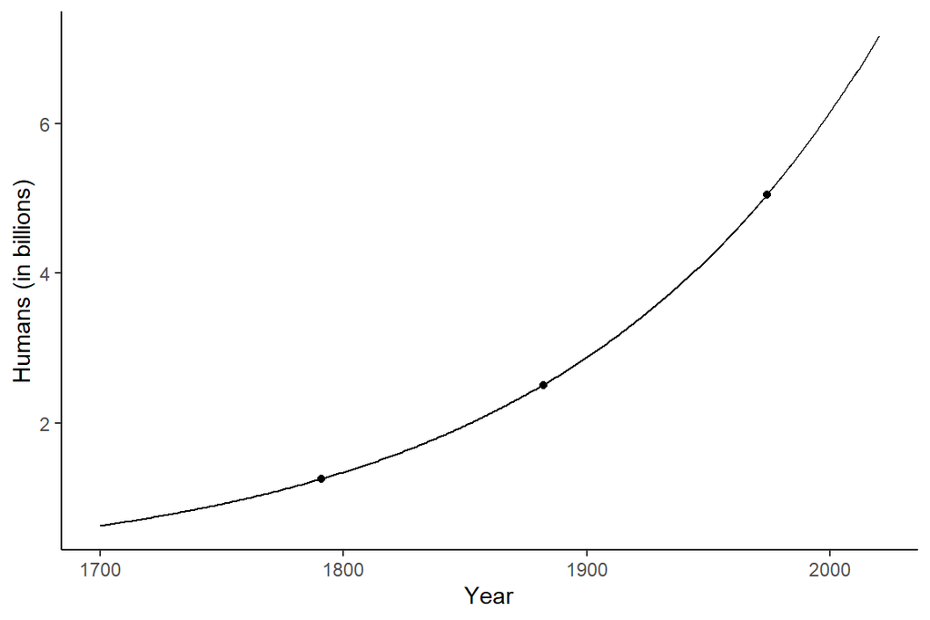

```r
# Vincent's answer


max_double <- log(create_pop_data()$population[nrow(create_pop_data())]/create_pop_data()$population[1])/log(2)

doublings <- create_pop_data()$population[1]*2^(1:round(max_double))

##Lot's of adhoc stuff here

data <- create_pop_data()
data$double <- NA

for (i in 1:(length(doublings)-1)){

  temp <- which(abs(create_pop_data()$population-doublings[i])==min(abs(create_pop_data()$population-doublings[i])))

  data$double[temp] <- 1

}

graph1c <- graph1b +
           geom_point(data=data, aes(shape=as.factor(double))) +
           theme_classic() +
           theme(legend.position = "none")
```

4. What will prevent humans from outweighing the planet by the end of this century? What controls human population growth? Do these controls vary spatially across the planet? See Cohen [33] to get going.

We known from ESM201 that there are four assumptions behind the exponential growth model: (1) homogeneous population, (2) continuous reproduction, (3) homogeneous habitat and (4) unlimited resources.

Loosening assumption (4) will get us the density-dependent growth model.

### 1.4. R functions

Find the R functions in Chapter 1. Demonstrate their uses.